# Exploratory Data Analysis

This document contains information and code from the coursera “Exploratory Data Analysis Course”

# Week 1

The first week focusses on R’s base plotting system.

## Classes

Below we see how to create an empty scatter plot so as to add subsets one by one with differing colours.

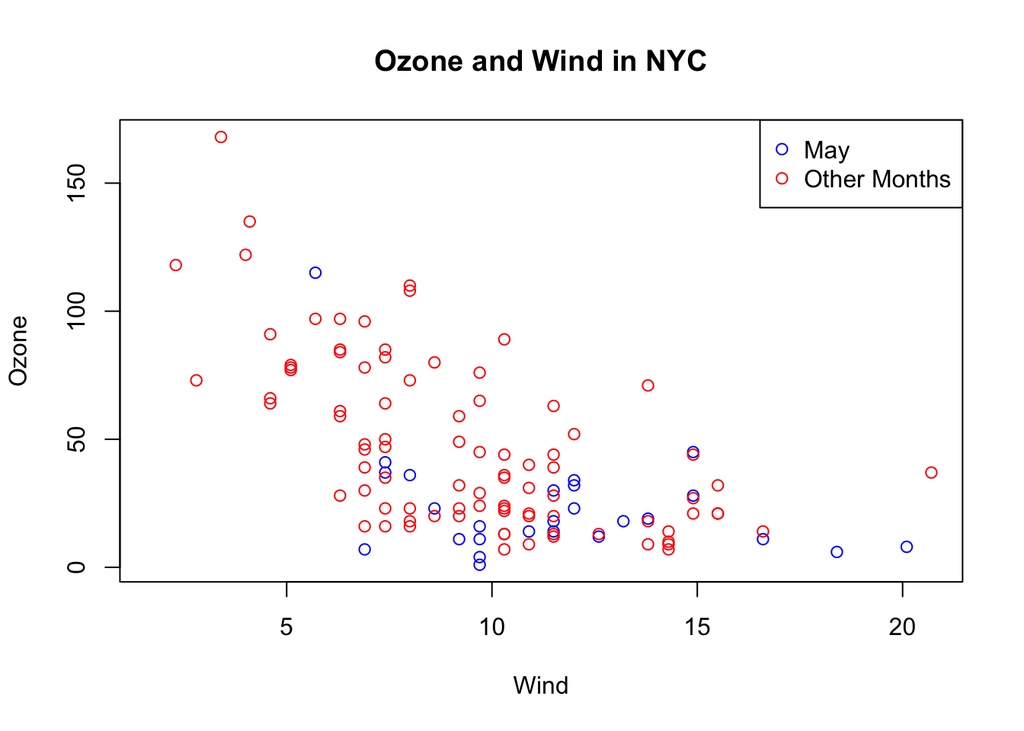

```r
library(datasets)
with(airquality, plot(Wind,Ozone,main="Ozone and Wind in NYC", type="n"))
with(subset(airquality, Month==5), points(Wind,Ozone,col="blue"))
with(subset(airquality, Month!=5), points(Wind,Ozone,col="red"))
legend("topright",pch=1,col=c("blue", "red"), legend = c("May", "Other Months"))
```

From here, adding a regression line is simple:

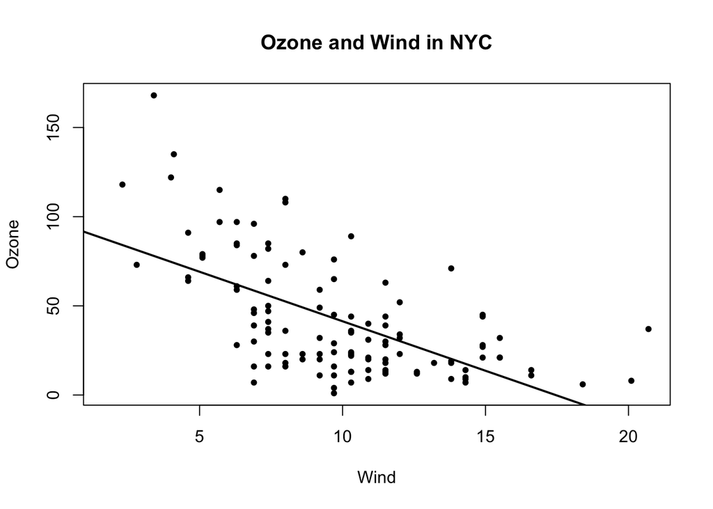

```r
with(airquality, plot(Wind,Ozone,main="Ozone and Wind in NYC", pch=20))
model <- lm(Ozone ~ Wind, airquality)
abline(model,lwd=2)
```

Often we want multiple plots on asingle device, this is achieved using the `par()` command:

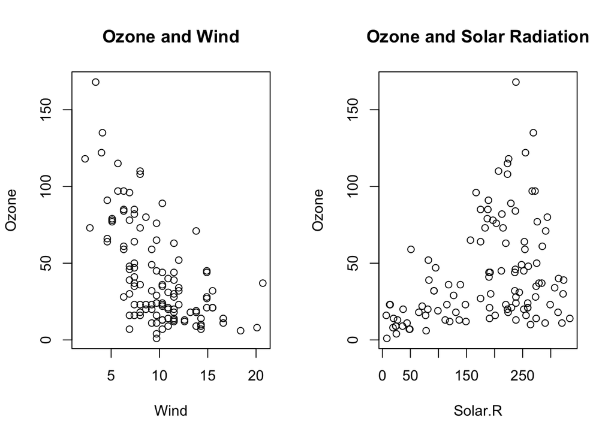

```r
par(mfrow = c(1,2))
with(airquality, {
  plot(Wind, Ozone, main = "Ozone and Wind")
  plot(Solar.R, Ozone, main = "Ozone and Solar Radiation")
})
```

This is highly customisable:

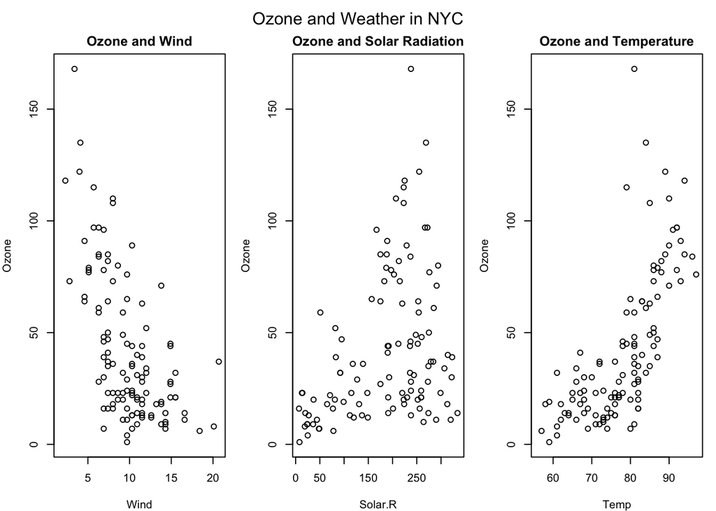

```r
par(mfrow = c(1,3), mar = c(4,4,2,1), oma = c(0,0,2,0))
with(airquality, {
  plot(Wind, Ozone, main = "Ozone and Wind")
  plot(Solar.R, Ozone, main = "Ozone and Solar Radiation")
  plot(Temp,Ozone, main = "Ozone and Temperature")
  mtext("Ozone and Weather in NYC", outer =T)
})
```

There are actually two approaches to creating a plot. The first, we have been using already and involves calling a function like `plot(), xyplot() or qplot()`. This automatically sends the plot to the screen after which we annotate it if necessary.

The second method explicitly launches a graphics device. The device MUST then be explicitly closed after annotation:

```
pdf(file="myplot.pdf") # Open PDF device and create file
with(faithful, plot(eruptions, waiting)) # Create plot (sent to file)
title(main="Old Faithful Geyser data") # Annotate plot
dev.off() # Close the pdf file device
```

If you are editing a plot using the screen device and you lie the look of it, you can use the `dev.copy()` function to copy it to a file device. Don’t forget to close the file device though!

```
with(faithful, plot(eruptions,waiting)) # Create plot on screen device
title(main = "Old Faithful Geyser data") # Add a main title
dev.copy(png, file="geyserplot.png") # coply plot to PNG file
dev.off()
})
```

## Course Project 1

This assignment uses data from the [UC Irvine Machine Learning Repository](http://archive.ics.uci.edu/ml/), a popular repository for machine learning datasets. In particular, we will be using the “Individual household electric power consumption Data Set” which I have made available on the course web site:

Dataset: [Electric power consumption](https://d396qusza40orc.cloudfront.net/exdata%2Fdata%2Fhousehold_power_consumption.zip)

Description: Measurements of electric power consumption in one household with a one-minute sampling rate over a period of almost 4 years. Different electrical quantities and some sub-metering values are available.

The following descriptions of the 9 variables in the dataset are taken from the [UCI web site](https://archive.ics.uci.edu/ml/datasets/Individual+household+electric+power+consumption):

1. **Date**: Date in format dd/mm/yyyy
2. **Time**: time in format hh:mm:ss
3. **Global_active_power**: household global minute-averaged active power (in kilowatt)
4. **Global_reactive_power**: household global minute-averaged reactive power (in kilowatt)
5. **Voltage**: minute-averaged voltage (in volt)
6. **Global_intensity**: household global minute-averaged current intensity (in ampere)
7. **Sub_metering_1**: energy sub-metering No. 1 (in watt-hour of active energy). It corresponds to the kitchen, containing mainly a dishwasher, an oven and a microwave (hot plates are not electric but gas powered).
8. **Sub_metering_2**: energy sub-metering No. 2 (in watt-hour of active energy). It corresponds to the laundry room, containing a washing-machine, a tumble-drier, a refrigerator and a light.
9. **Sub_metering_3**: energy sub-metering No. 3 (in watt-hour of active energy). It corresponds to an electric water-heater and an air-conditioner.

### Loading the Data

Read raw data into R:

```r
data <- read.table("household_power_consumption.txt", header=T, sep=";", quote="",na.strings = "?", nrows=2075260)
```

Convert date and time collumns from charater strings to the Date/Time class:

```r
data$DateTime <- as.POSIXct(paste(data$Date,data$Time), format="%d/%m/%Y %H:%M:%S")
```

Subset the date for the period that we’re interested in:

```r
data <- subset(data, DateTime >= as.POSIXct("2007-02-01 00:00:00") & DateTime < as.POSIXct("2007-02-03 00:00:00"))
```

Create the first Plot:

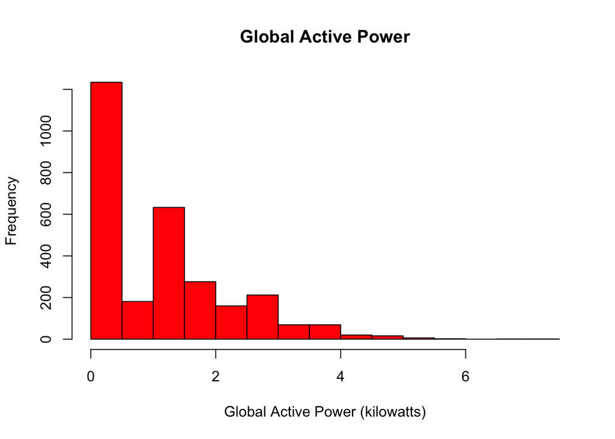

```r
with(data, hist(Global_active_power, main="Global Active Power", xlab="Global Active Power (kilowatts)", col="red"))
```

…and the second

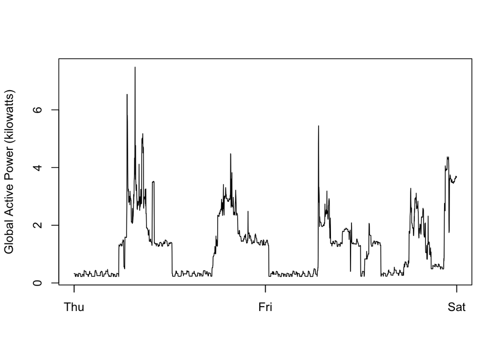

```r
with(data, plot(Global_active_power ~ DateTime, main="", xlab="", ylab="Global Active Power (kilowatts)", type="l"))
```

…and the third

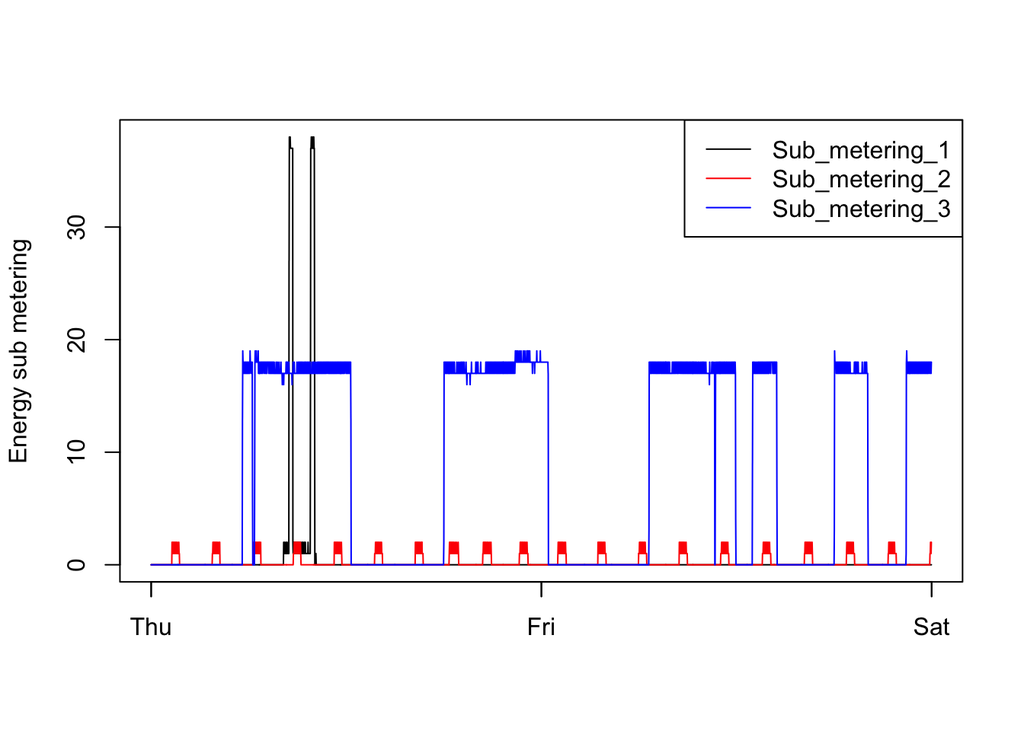

```r
with(data, plot(Sub_metering_1 ~ DateTime, main="", xlab="", ylab="Energy sub metering",type="n"))
with(data, lines(Sub_metering_1 ~ DateTime, col="black"))
with(data, lines(Sub_metering_2 ~ DateTime, col="red"))
with(data, lines(Sub_metering_3 ~ DateTime, col="blue"))
legend("topright",lwd=1,col=c("black", "red", "blue"), legend = c("Sub_metering_1", "Sub_metering_2", "Sub_metering_3"))
```

…and the final plot

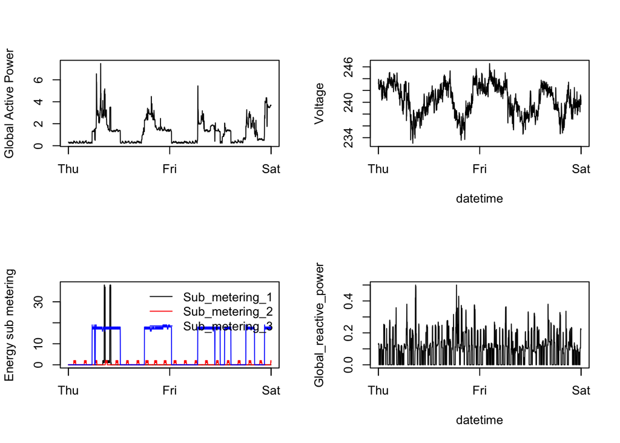

```r
par(mfrow = c(2,2))
with(data, plot(Global_active_power ~ DateTime, main="", xlab="", ylab="Global Active Power", type="l"))
with(data, plot(Voltage ~ DateTime, main="", ylab="Voltage", xlab="datetime", type="l"))
with(data, plot(Sub_metering_1 ~ DateTime, main="", xlab="", ylab="Energy sub metering", type="n"))
with(data, lines(Sub_metering_1 ~ DateTime, col="black"))
with(data, lines(Sub_metering_2 ~ DateTime, col="red"))
with(data, lines(Sub_metering_3 ~ DateTime, col="blue"))
legend("topright",lwd=1,col=c("black", "red", "blue"), legend = c("Sub_metering_1", "Sub_metering_2", "Sub_metering_3"), bty="n")
with(data, plot(Global_reactive_power ~ DateTime, main="", xlab="datetime", type="l"))
```